# Risk Factor Analysis

## Outcome Variable

**Outcome Variable:** whz

## Predictor Variables

**Intervention Variable:** perdiar6

**Adjustment Set:**

unadjusted

## Stratifying Variables

The analysis was stratified on these variable(s):

- agecat
- studyid
- country

## Data Summary

| agecat | studyid | country | perdiar6 | n_cell | n |
| --- | --- | --- | --- | --- | --- |
| Birth | CMIN | BANGLADESH | 0% | 10 | 19 |
| Birth | CMIN | BANGLADESH | (0%, 5%] | 3 | 19 |
| Birth | CMIN | BANGLADESH | >5% | 6 | 19 |
| Birth | CONTENT | PERU | 0% | 0 | 2 |
| Birth | CONTENT | PERU | (0%, 5%] | 1 | 2 |
| Birth | CONTENT | PERU | >5% | 1 | 2 |
| Birth | EE | PAKISTAN | 0% | 164 | 177 |
| Birth | EE | PAKISTAN | (0%, 5%] | 11 | 177 |
| Birth | EE | PAKISTAN | >5% | 2 | 177 |
| Birth | MAL-ED | BANGLADESH | 0% | 65 | 215 |
| Birth | MAL-ED | BANGLADESH | (0%, 5%] | 86 | 215 |
| Birth | MAL-ED | BANGLADESH | >5% | 64 | 215 |
| Birth | MAL-ED | BRAZIL | 0% | 54 | 62 |
| Birth | MAL-ED | BRAZIL | (0%, 5%] | 6 | 62 |
| Birth | MAL-ED | BRAZIL | >5% | 2 | 62 |
| Birth | MAL-ED | INDIA | 0% | 11 | 45 |
| Birth | MAL-ED | INDIA | (0%, 5%] | 23 | 45 |
| Birth | MAL-ED | INDIA | >5% | 11 | 45 |
| Birth | MAL-ED | NEPAL | 0% | 8 | 26 |
| Birth | MAL-ED | NEPAL | (0%, 5%] | 10 | 26 |
| Birth | MAL-ED | NEPAL | >5% | 8 | 26 |
| Birth | MAL-ED | PERU | 0% | 67 | 228 |
| Birth | MAL-ED | PERU | (0%, 5%] | 69 | 228 |
| Birth | MAL-ED | PERU | >5% | 92 | 228 |
| Birth | MAL-ED | SOUTH AFRICA | 0% | 85 | 112 |
| Birth | MAL-ED | SOUTH AFRICA | (0%, 5%] | 23 | 112 |
| Birth | MAL-ED | SOUTH AFRICA | >5% | 4 | 112 |
| Birth | MAL-ED | TANZANIA, UNITED REPUBLIC OF | 0% | 51 | 115 |
| Birth | MAL-ED | TANZANIA, UNITED REPUBLIC OF | (0%, 5%] | 44 | 115 |
| Birth | MAL-ED | TANZANIA, UNITED REPUBLIC OF | >5% | 20 | 115 |

[output cut: 87 more lines]

The following strata were considered:

- agecat: 24 months, studyid: CMIN, country: BANGLADESH
- agecat: 24 months, studyid: CONTENT, country: PERU
- agecat: 24 months, studyid: EE, country: PAKISTAN
- agecat: 24 months, studyid: MAL-ED, country: BANGLADESH
- agecat: 24 months, studyid: MAL-ED, country: BRAZIL
- agecat: 24 months, studyid: MAL-ED, country: INDIA
- agecat: 24 months, studyid: MAL-ED, country: NEPAL
- agecat: 24 months, studyid: MAL-ED, country: PERU
- agecat: 24 months, studyid: MAL-ED, country: SOUTH AFRICA
- agecat: 24 months, studyid: MAL-ED, country: TANZANIA, UNITED REPUBLIC OF
- agecat: 24 months, studyid: NIH-Birth, country: BANGLADESH
- agecat: 24 months, studyid: NIH-Crypto, country: BANGLADESH
- agecat: 24 months, studyid: PROVIDE, country: BANGLADESH
- agecat: 6 months, studyid: CMIN, country: BANGLADESH
- agecat: 6 months, studyid: CONTENT, country: PERU
- agecat: 6 months, studyid: EE, country: PAKISTAN
- agecat: 6 months, studyid: MAL-ED, country: BANGLADESH
- agecat: 6 months, studyid: MAL-ED, country: BRAZIL
- agecat: 6 months, studyid: MAL-ED, country: INDIA
- agecat: 6 months, studyid: MAL-ED, country: NEPAL
- agecat: 6 months, studyid: MAL-ED, country: PERU
- agecat: 6 months, studyid: MAL-ED, country: SOUTH AFRICA
- agecat: 6 months, studyid: MAL-ED, country: TANZANIA, UNITED REPUBLIC OF
- agecat: 6 months, studyid: NIH-Birth, country: BANGLADESH
- agecat: 6 months, studyid: NIH-Crypto, country: BANGLADESH
- agecat: 6 months, studyid: PROVIDE, country: BANGLADESH
- agecat: Birth, studyid: CMIN, country: BANGLADESH
- agecat: Birth, studyid: CONTENT, country: PERU
- agecat: Birth, studyid: EE, country: PAKISTAN
- agecat: Birth, studyid: MAL-ED, country: BANGLADESH
- agecat: Birth, studyid: MAL-ED, country: BRAZIL
- agecat: Birth, studyid: MAL-ED, country: INDIA
- agecat: Birth, studyid: MAL-ED, country: NEPAL
- agecat: Birth, studyid: MAL-ED, country: PERU
- agecat: Birth, studyid: MAL-ED, country: SOUTH AFRICA
- agecat: Birth, studyid: MAL-ED, country: TANZANIA, UNITED REPUBLIC OF
- agecat: Birth, studyid: NIH-Birth, country: BANGLADESH
- agecat: Birth, studyid: NIH-Crypto, country: BANGLADESH
- agecat: Birth, studyid: PROVIDE, country: BANGLADESH

### Dropped Strata

Some strata were dropped due to rare outcomes:

- agecat: Birth, studyid: CMIN, country: BANGLADESH
- agecat: Birth, studyid: CONTENT, country: PERU
- agecat: Birth, studyid: EE, country: PAKISTAN
- agecat: Birth, studyid: MAL-ED, country: BRAZIL
- agecat: Birth, studyid: MAL-ED, country: SOUTH AFRICA
- agecat: 6 months, studyid: EE, country: PAKISTAN
- agecat: 6 months, studyid: MAL-ED, country: BRAZIL
- agecat: 24 months, studyid: EE, country: PAKISTAN
- agecat: 24 months, studyid: MAL-ED, country: BRAZIL

## Methods Detail

We’re interested in the causal parameters $E[Y_a]$ for all values of $a \in \mathcal{A}$. These parameters represent the mean outcome if, possibly contrary to fact, we intervened to set all units to have $A=a$. Under the randomization and positivity assumptions, these are identified by the statistical parameters $\psi_a=E_W[E_{Y|A,W}(Y|A=a,W)]$. In addition, we’re interested in the mean of $Y$, $E[Y]$ under no intervention (the observed mean). We will estimate these parameters by using SuperLearner to fit the relevant likelihood factors – $E_{Y|A,W}(Y|A=a,W)$ and $p(A=a|W)$, and then updating our likelihood fit using a joint TMLE.

For unadjusted analyses ($W=\{\}$), initial likelihoods were estimated using Lrnr_glm to estimate the simple $E(Y|A)$ and Lrnr_mean to estimate $p(A)$. For adjusted analyses, a small library containing Lrnr_glmnet, Lrnr_xgboost, and Lrnr_mean was used.

Having estimated these parameters, we will then use the delta method to estimate relative risks and attributable risks relative to a prespecified baseline level of $A$.

# Results Detail

## Results Plots

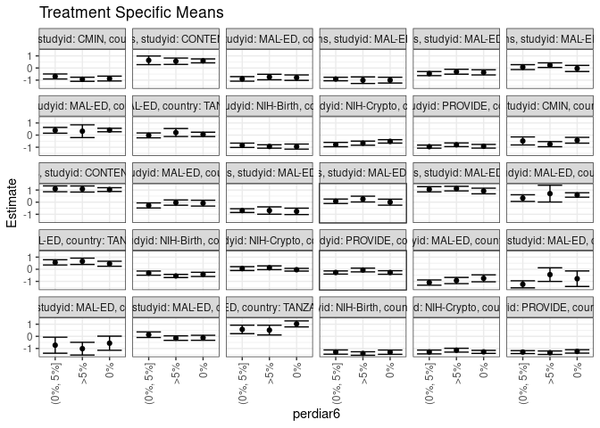

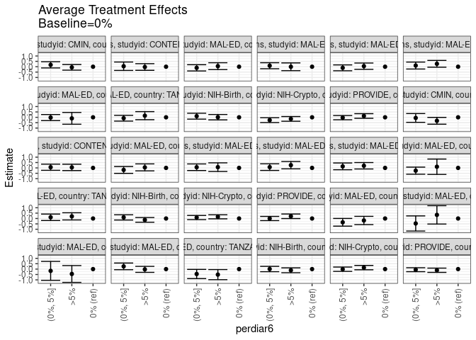

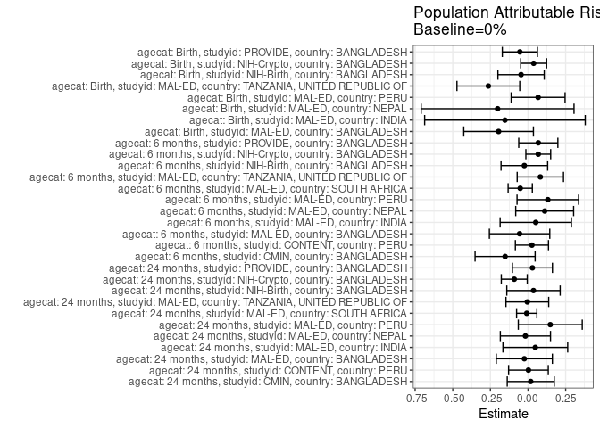

## Results Table

### Parameter: TSM

| agecat | studyid | country | intervention_level | baseline_level | estimate | ci_lower | ci_upper |
| --- | --- | --- | --- | --- | --- | --- | --- |
| Birth | MAL-ED | BANGLADESH | 0% | NA | -0.7463077 | -1.0329570 | -0.4596584 |
| Birth | MAL-ED | BANGLADESH | (0%, 5%] | NA | -1.0988953 | -1.3139951 | -0.8837956 |
| Birth | MAL-ED | BANGLADESH | >5% | NA | -0.9294531 | -1.1844604 | -0.6744459 |
| Birth | MAL-ED | INDIA | 0% | NA | -0.7790909 | -1.4191424 | -0.1390394 |
| Birth | MAL-ED | INDIA | (0%, 5%] | NA | -1.2404348 | -1.5310948 | -0.9497747 |
| Birth | MAL-ED | INDIA | >5% | NA | -0.4418182 | -1.0034092 | 0.1197728 |
| Birth | MAL-ED | NEPAL | 0% | NA | -0.5662500 | -1.1479485 | 0.0154485 |
| Birth | MAL-ED | NEPAL | (0%, 5%] | NA | -0.7310000 | -1.3926378 | -0.0693622 |
| Birth | MAL-ED | NEPAL | >5% | NA | -1.0175000 | -1.5408661 | -0.4941339 |
| Birth | MAL-ED | PERU | 0% | NA | -0.1191045 | -0.3254996 | 0.0872906 |
| Birth | MAL-ED | PERU | (0%, 5%] | NA | 0.1349275 | -0.0967958 | 0.3666509 |
| Birth | MAL-ED | PERU | >5% | NA | -0.1433696 | -0.3299566 | 0.0432175 |
| Birth | MAL-ED | TANZANIA, UNITED REPUBLIC OF | 0% | NA | 1.0260784 | 0.7788588 | 1.2732980 |
| Birth | MAL-ED | TANZANIA, UNITED REPUBLIC OF | (0%, 5%] | NA | 0.5700000 | 0.2205515 | 0.9194485 |
| Birth | MAL-ED | TANZANIA, UNITED REPUBLIC OF | >5% | NA | 0.5135000 | 0.1132895 | 0.9137105 |
| Birth | NIH-Birth | BANGLADESH | 0% | NA | -1.3062667 | -1.4818587 | -1.1306746 |
| Birth | NIH-Birth | BANGLADESH | (0%, 5%] | NA | -1.2980702 | -1.4741349 | -1.1220054 |
| Birth | NIH-Birth | BANGLADESH | >5% | NA | -1.4173108 | -1.5629379 | -1.2716836 |
| Birth | NIH-Crypto | BANGLADESH | 0% | NA | -1.2815362 | -1.4059094 | -1.1571630 |
| Birth | NIH-Crypto | BANGLADESH | (0%, 5%] | NA | -1.2908125 | -1.4484391 | -1.1331859 |
| Birth | NIH-Crypto | BANGLADESH | >5% | NA | -1.1433416 | -1.3026371 | -0.9840461 |
| Birth | PROVIDE | BANGLADESH | 0% | NA | -1.2441875 | -1.3833716 | -1.1050034 |
| Birth | PROVIDE | BANGLADESH | (0%, 5%] | NA | -1.2991262 | -1.4200041 | -1.1782484 |
| Birth | PROVIDE | BANGLADESH | >5% | NA | -1.3499398 | -1.4912945 | -1.2085851 |
| 6 months | CMIN | BANGLADESH | 0% | NA | -0.4256379 | -0.6637716 | -0.1875041 |
| 6 months | CMIN | BANGLADESH | (0%, 5%] | NA | -0.4834483 | -0.8149497 | -0.1519469 |
| 6 months | CMIN | BANGLADESH | >5% | NA | -0.7495032 | -0.9584404 | -0.5405661 |
| 6 months | CONTENT | PERU | 0% | NA | 1.0385522 | 0.8816859 | 1.1954184 |
| 6 months | CONTENT | PERU | (0%, 5%] | NA | 1.1025698 | 0.8611466 | 1.3439930 |
| 6 months | CONTENT | PERU | >5% | NA | 1.0878596 | 0.8366786 | 1.3390407 |

[output cut: 60 more lines]

### Parameter: E(Y)

| agecat | studyid | country | intervention_level | baseline_level | estimate | ci_lower | ci_upper |
| --- | --- | --- | --- | --- | --- | --- | --- |
| Birth | MAL-ED | BANGLADESH | NA | NA | -0.9418605 | -1.0869834 | -0.7967375 |
| Birth | MAL-ED | INDIA | NA | NA | -0.9324444 | -1.2067907 | -0.6580982 |
| Birth | MAL-ED | NEPAL | NA | NA | -0.7684615 | -1.1257770 | -0.4111460 |
| Birth | MAL-ED | PERU | NA | NA | -0.0520175 | -0.1725298 | 0.0684947 |
| Birth | MAL-ED | TANZANIA, UNITED REPUBLIC OF | NA | NA | 0.7624348 | 0.5710709 | 0.9537986 |
| Birth | NIH-Birth | BANGLADESH | NA | NA | -1.3525437 | -1.4473932 | -1.2576942 |
| Birth | NIH-Crypto | BANGLADESH | NA | NA | -1.2441513 | -1.3281130 | -1.1601897 |
| Birth | PROVIDE | BANGLADESH | NA | NA | -1.2984586 | -1.3752758 | -1.2216415 |
| 6 months | CMIN | BANGLADESH | NA | NA | -0.5780453 | -0.7226627 | -0.4334279 |
| 6 months | CONTENT | PERU | NA | NA | 1.0644279 | 0.9468682 | 1.1819876 |
| 6 months | MAL-ED | BANGLADESH | NA | NA | -0.1376763 | -0.2664642 | -0.0088885 |
| 6 months | MAL-ED | INDIA | NA | NA | -0.7079979 | -0.8344175 | -0.5815783 |
| 6 months | MAL-ED | NEPAL | NA | NA | 0.1104308 | -0.0208643 | 0.2417259 |
| 6 months | MAL-ED | PERU | NA | NA | 1.0528816 | 0.9313005 | 1.1744626 |
| 6 months | MAL-ED | SOUTH AFRICA | NA | NA | 0.5421785 | 0.3900443 | 0.6943126 |
| 6 months | MAL-ED | TANZANIA, UNITED REPUBLIC OF | NA | NA | 0.5362213 | 0.4049390 | 0.6675036 |
| 6 months | NIH-Birth | BANGLADESH | NA | NA | -0.4474038 | -0.5378167 | -0.3569909 |
| 6 months | NIH-Crypto | BANGLADESH | NA | NA | 0.0297622 | -0.0491685 | 0.1086930 |
| 6 months | PROVIDE | BANGLADESH | NA | NA | -0.1990907 | -0.2817968 | -0.1163845 |
| 24 months | CMIN | BANGLADESH | NA | NA | -0.8535391 | -0.9644236 | -0.7426546 |
| 24 months | CONTENT | PERU | NA | NA | 0.5902439 | 0.4560143 | 0.7244735 |
| 24 months | MAL-ED | BANGLADESH | NA | NA | -0.8192925 | -0.9412667 | -0.6973182 |
| 24 months | MAL-ED | INDIA | NA | NA | -0.9516520 | -1.0670654 | -0.8362385 |
| 24 months | MAL-ED | NEPAL | NA | NA | -0.3749123 | -0.4886073 | -0.2612173 |
| 24 months | MAL-ED | PERU | NA | NA | 0.1111982 | -0.0118399 | 0.2342362 |
| 24 months | MAL-ED | SOUTH AFRICA | NA | NA | 0.4090301 | 0.2879441 | 0.5301161 |
| 24 months | MAL-ED | TANZANIA, UNITED REPUBLIC OF | NA | NA | 0.0547975 | -0.0703378 | 0.1799328 |
| 24 months | NIH-Birth | BANGLADESH | NA | NA | -0.9115790 | -1.0095022 | -0.8136559 |
| 24 months | NIH-Crypto | BANGLADESH | NA | NA | -0.6103502 | -0.7050157 | -0.5156847 |
| 24 months | PROVIDE | BANGLADESH | NA | NA | -0.8928670 | -0.9755153 | -0.8102187 |

### Parameter: ATE

| agecat | studyid | country | intervention_level | baseline_level | estimate | ci_lower | ci_upper |
| --- | --- | --- | --- | --- | --- | --- | --- |
| Birth | MAL-ED | BANGLADESH | 0% | 0% | 0.0000000 | 0.0000000 | 0.0000000 |
| Birth | MAL-ED | BANGLADESH | (0%, 5%] | 0% | -0.3525877 | -0.7109669 | 0.0057916 |
| Birth | MAL-ED | BANGLADESH | >5% | 0% | -0.1831454 | -0.5668074 | 0.2005165 |
| Birth | MAL-ED | INDIA | 0% | 0% | 0.0000000 | 0.0000000 | 0.0000000 |
| Birth | MAL-ED | INDIA | (0%, 5%] | 0% | -0.4613439 | -1.1643014 | 0.2416136 |
| Birth | MAL-ED | INDIA | >5% | 0% | 0.3372727 | -0.5142262 | 1.1887717 |
| Birth | MAL-ED | NEPAL | 0% | 0% | 0.0000000 | 0.0000000 | 0.0000000 |
| Birth | MAL-ED | NEPAL | (0%, 5%] | 0% | -0.1647500 | -1.0457368 | 0.7162368 |
| Birth | MAL-ED | NEPAL | >5% | 0% | -0.4512500 | -1.2337366 | 0.3312366 |
| Birth | MAL-ED | PERU | 0% | 0% | 0.0000000 | 0.0000000 | 0.0000000 |
| Birth | MAL-ED | PERU | (0%, 5%] | 0% | 0.2540320 | -0.0562818 | 0.5643458 |
| Birth | MAL-ED | PERU | >5% | 0% | -0.0242651 | -0.3024982 | 0.2539680 |
| Birth | MAL-ED | TANZANIA, UNITED REPUBLIC OF | 0% | 0% | 0.0000000 | 0.0000000 | 0.0000000 |
| Birth | MAL-ED | TANZANIA, UNITED REPUBLIC OF | (0%, 5%] | 0% | -0.4560784 | -0.8841342 | -0.0280226 |
| Birth | MAL-ED | TANZANIA, UNITED REPUBLIC OF | >5% | 0% | -0.5125784 | -0.9829889 | -0.0421680 |
| Birth | NIH-Birth | BANGLADESH | 0% | 0% | 0.0000000 | 0.0000000 | 0.0000000 |
| Birth | NIH-Birth | BANGLADESH | (0%, 5%] | 0% | 0.0081965 | -0.2404627 | 0.2568557 |
| Birth | NIH-Birth | BANGLADESH | >5% | 0% | -0.1110441 | -0.3391665 | 0.1170783 |
| Birth | NIH-Crypto | BANGLADESH | 0% | 0% | 0.0000000 | 0.0000000 | 0.0000000 |
| Birth | NIH-Crypto | BANGLADESH | (0%, 5%] | 0% | -0.0092763 | -0.2100618 | 0.1915093 |
| Birth | NIH-Crypto | BANGLADESH | >5% | 0% | 0.1381946 | -0.0639037 | 0.3402930 |
| Birth | PROVIDE | BANGLADESH | 0% | 0% | 0.0000000 | 0.0000000 | 0.0000000 |
| Birth | PROVIDE | BANGLADESH | (0%, 5%] | 0% | -0.0549387 | -0.2392853 | 0.1294078 |
| Birth | PROVIDE | BANGLADESH | >5% | 0% | -0.1057523 | -0.3041291 | 0.0926245 |
| 6 months | CMIN | BANGLADESH | 0% | 0% | 0.0000000 | 0.0000000 | 0.0000000 |
| 6 months | CMIN | BANGLADESH | (0%, 5%] | 0% | -0.0578104 | -0.4659781 | 0.3503573 |
| 6 months | CMIN | BANGLADESH | >5% | 0% | -0.3238653 | -0.6406656 | -0.0070651 |
| 6 months | CONTENT | PERU | 0% | 0% | 0.0000000 | 0.0000000 | 0.0000000 |
| 6 months | CONTENT | PERU | (0%, 5%] | 0% | 0.0640176 | -0.2238924 | 0.3519276 |
| 6 months | CONTENT | PERU | >5% | 0% | 0.0493075 | -0.2468326 | 0.3454476 |

[output cut: 60 more lines]

### Parameter: PAR

| agecat | studyid | country | intervention_level | baseline_level | estimate | ci_lower | ci_upper |
| --- | --- | --- | --- | --- | --- | --- | --- |
| Birth | MAL-ED | BANGLADESH | 0% | NA | -0.1955528 | -0.4269520 | 0.0358465 |
| Birth | MAL-ED | INDIA | 0% | NA | -0.1533535 | -0.6868802 | 0.3801731 |
| Birth | MAL-ED | NEPAL | 0% | NA | -0.2022115 | -0.7099692 | 0.3055462 |
| Birth | MAL-ED | PERU | 0% | NA | 0.0670869 | -0.1120385 | 0.2462123 |
| Birth | MAL-ED | TANZANIA, UNITED REPUBLIC OF | 0% | NA | -0.2636436 | -0.4722798 | -0.0550074 |
| Birth | NIH-Birth | BANGLADESH | 0% | NA | -0.0462770 | -0.2000889 | 0.1075348 |
| Birth | NIH-Crypto | BANGLADESH | 0% | NA | 0.0373849 | -0.0487633 | 0.1235331 |
| Birth | PROVIDE | BANGLADESH | 0% | NA | -0.0542711 | -0.1709786 | 0.0624363 |
| 6 months | CMIN | BANGLADESH | 0% | NA | -0.1524074 | -0.3519488 | 0.0471340 |
| 6 months | CONTENT | PERU | 0% | NA | 0.0258757 | -0.0841402 | 0.1358917 |
| 6 months | MAL-ED | BANGLADESH | 0% | NA | -0.0561036 | -0.2567322 | 0.1445251 |
| 6 months | MAL-ED | INDIA | 0% | NA | 0.0514188 | -0.1853557 | 0.2881933 |
| 6 months | MAL-ED | NEPAL | 0% | NA | 0.1105350 | -0.0817941 | 0.3028640 |
| 6 months | MAL-ED | PERU | 0% | NA | 0.1314477 | -0.0729758 | 0.3358712 |
| 6 months | MAL-ED | SOUTH AFRICA | 0% | NA | -0.0518040 | -0.1322455 | 0.0286376 |
| 6 months | MAL-ED | TANZANIA, UNITED REPUBLIC OF | 0% | NA | 0.0817928 | -0.0720816 | 0.2356671 |
| 6 months | NIH-Birth | BANGLADESH | 0% | NA | -0.0244968 | -0.1794150 | 0.1304214 |
| 6 months | NIH-Crypto | BANGLADESH | 0% | NA | 0.0680027 | -0.0144345 | 0.1504399 |
| 6 months | PROVIDE | BANGLADESH | 0% | NA | 0.0682342 | -0.0617541 | 0.1982225 |
| 24 months | CMIN | BANGLADESH | 0% | NA | 0.0180491 | -0.1381622 | 0.1742604 |
| 24 months | CONTENT | PERU | 0% | NA | 0.0026844 | -0.1291057 | 0.1344745 |
| 24 months | MAL-ED | BANGLADESH | 0% | NA | -0.0245268 | -0.2108405 | 0.1617869 |
| 24 months | MAL-ED | INDIA | 0% | NA | 0.0484522 | -0.1667804 | 0.2636848 |
| 24 months | MAL-ED | NEPAL | 0% | NA | -0.0173798 | -0.1840510 | 0.1492914 |
| 24 months | MAL-ED | PERU | 0% | NA | 0.1477862 | -0.0646916 | 0.3602641 |
| 24 months | MAL-ED | SOUTH AFRICA | 0% | NA | -0.0086347 | -0.0759944 | 0.0587251 |
| 24 months | MAL-ED | TANZANIA, UNITED REPUBLIC OF | 0% | NA | -0.0046228 | -0.1465723 | 0.1373267 |
| 24 months | NIH-Birth | BANGLADESH | 0% | NA | 0.0362558 | -0.1410196 | 0.2135313 |
| 24 months | NIH-Crypto | BANGLADESH | 0% | NA | -0.0914332 | -0.1776713 | -0.0051951 |
| 24 months | PROVIDE | BANGLADESH | 0% | NA | 0.0292572 | -0.1036326 | 0.1621470 |